# Project1

```python
import json
import csv
import pandas as pd

review = pd.read_json('yelp_academic_dataset_review.json', lines=True, nrows = 1000000)
business = pd.read_json('yelp_academic_dataset_business.json', lines=True, nrows = 1000000)
```

```python
review
```

|  | review_id | user_id | business_id | stars | useful | funny | cool | text | date |
| --- | --- | --- | --- | --- | --- | --- | --- | --- | --- |
| 0 | KU_O5udG6zpxOg-VcAEodg | mh_-eMZ6K5RLWhZyISBhwA | XQfwVwDr-v0ZS3_CbbE5Xw | 3 | 0 | 0 | 0 | If you decide to eat here, just be aware it is... | 2018-07-07 22:09:11 |
| 1 | BiTunyQ73aT9WBnpR9DZGw | OyoGAe7OKpv6SyGZT5g77Q | 7ATYjTIgM3jUlt4UM3IypQ | 5 | 1 | 0 | 1 | I've taken a lot of spin classes over the year... | 2012-01-03 15:28:18 |
| 2 | saUsX_uimxRlCVr67Z4Jig | 8g_iMtfSiwikVnbP2etR0A | YjUWPpI6HXG530lwP-fb2A | 3 | 0 | 0 | 0 | Family diner. Had the buffet. Eclectic assortm... | 2014-02-05 20:30:30 |
| 3 | AqPFMleE6RsU23_auESxiA | _7bHUi9Uuf5__HHc_Q8guQ | kxX2SOes4o-D3ZQBkiMRfA | 5 | 1 | 0 | 1 | Wow! Yummy, different, delicious. Our favo... | 2015-01-04 00:01:03 |
| 4 | Sx8TMOWLNuJBWer-0pcmoA | bcjbaE6dDog4jkNY91ncLQ | e4Vwtrqf-wpJfwesgvdgxQ | 4 | 1 | 0 | 1 | Cute interior and owner (?) gave us tour of up... | 2017-01-14 20:54:15 |
| ... | ... | ... | ... | ... | ... | ... | ... | ... | ... |
| 999995 | t-2o35kr7Q9DSaeuKhaDuQ | oX7o1TH0PHUWp9r9ry9_vw | jLn69WQupjsDKrbPw_nlGQ | 3 | 0 | 1 | 0 | Never really had any issues here other than th... | 2017-11-15 09:43:07 |
| 999996 | fLIwWCvdul9PNWYfJt5QWA | v8wlapFKVLs2qTYCGhCdiw | t6v8g8UeNiq3O2GoEc7R4Q | 4 | 0 | 0 | 0 | Fish recently moved a couple of doors down the... | 2014-09-03 18:27:33 |
| 999997 | ETAiy6wEM-r9ve4SKDhBpg | rLlYc1RzIBnOmnX3AbpEYw | ZYRul0i1bhOjirHED6Kd0w | 3 | 0 | 0 | 0 | I've been to South House around a dozen or so ... | 2016-02-20 22:25:29 |
| 999998 | 8OgvSXuc6KjAt2fSz9LuzA | eEH-8CEPU5ndPxDGzVfHiQ | onGXKwnxPLtKnO8yqQMPSA | 1 | 1 | 0 | 1 | Wow! I am shocked at these reviews. I have tri... | 2010-06-27 02:17:30 |
| 999999 | TQoVzNXqDkiDXgzlw8cyaQ | HYmGwYXvcYmW7dDjuWKJfw | 54vEFcAri3Wj6cdM4ljDBA | 4 | 2 | 1 | 0 | headed to St. Louis for a little getaway with ... | 2012-11-05 03:25:02 |

1000000 rows × 9 columns

```python
business
```

|  | business_id | name | address | city | state | postal_code | latitude | longitude | stars | review_count | is_open | attributes | categories | hours |
| --- | --- | --- | --- | --- | --- | --- | --- | --- | --- | --- | --- | --- | --- | --- |
| 0 | Pns2l4eNsfO8kk83dixA6A | Abby Rappoport, LAC, CMQ | 1616 Chapala St, Ste 2 | Santa Barbara | CA | 93101 | 34.426679 | -119.711197 | 5.0 | 7 | 0 | {'ByAppointmentOnly': 'True'} | Doctors, Traditional Chinese Medicine, Naturop... | None |
| 1 | mpf3x-BjTdTEA3yCZrAYPw | The UPS Store | 87 Grasso Plaza Shopping Center | Affton | MO | 63123 | 38.551126 | -90.335695 | 3.0 | 15 | 1 | {'BusinessAcceptsCreditCards': 'True'} | Shipping Centers, Local Services, Notaries, Ma... | {'Monday': '0:0-0:0', 'Tuesday': '8:0-18:30', ... |
| 2 | tUFrWirKiKi_TAnsVWINQQ | Target | 5255 E Broadway Blvd | Tucson | AZ | 85711 | 32.223236 | -110.880452 | 3.5 | 22 | 0 | {'BikeParking': 'True', 'BusinessAcceptsCredit... | Department Stores, Shopping, Fashion, Home & G... | {'Monday': '8:0-22:0', 'Tuesday': '8:0-22:0', ... |
| 3 | MTSW4McQd7CbVtyjqoe9mw | St Honore Pastries | 935 Race St | Philadelphia | PA | 19107 | 39.955505 | -75.155564 | 4.0 | 80 | 1 | {'RestaurantsDelivery': 'False', 'OutdoorSeati... | Restaurants, Food, Bubble Tea, Coffee & Tea, B... | {'Monday': '7:0-20:0', 'Tuesday': '7:0-20:0', ... |
| 4 | mWMc6_wTdE0EUBKIGXDVfA | Perkiomen Valley Brewery | 101 Walnut St | Green Lane | PA | 18054 | 40.338183 | -75.471659 | 4.5 | 13 | 1 | {'BusinessAcceptsCreditCards': 'True', 'Wheelc... | Brewpubs, Breweries, Food | {'Wednesday': '14:0-22:0', 'Thursday': '16:0-2... |
| ... | ... | ... | ... | ... | ... | ... | ... | ... | ... | ... | ... | ... | ... | ... |
| 150341 | IUQopTMmYQG-qRtBk-8QnA | Binh's Nails | 3388 Gateway Blvd | Edmonton | AB | T6J 5H2 | 53.468419 | -113.492054 | 3.0 | 13 | 1 | {'ByAppointmentOnly': 'False', 'RestaurantsPri... | Nail Salons, Beauty & Spas | {'Monday': '10:0-19:30', 'Tuesday': '10:0-19:3... |
| 150342 | c8GjPIOTGVmIemT7j5_SyQ | Wild Birds Unlimited | 2813 Bransford Ave | Nashville | TN | 37204 | 36.115118 | -86.766925 | 4.0 | 5 | 1 | {'BusinessAcceptsCreditCards': 'True', 'Restau... | Pets, Nurseries & Gardening, Pet Stores, Hobby... | {'Monday': '9:30-17:30', 'Tuesday': '9:30-17:3... |
| 150343 | _QAMST-NrQobXduilWEqSw | Claire's Boutique | 6020 E 82nd St, Ste 46 | Indianapolis | IN | 46250 | 39.908707 | -86.065088 | 3.5 | 8 | 1 | {'RestaurantsPriceRange2': '1', 'BusinessAccep... | Shopping, Jewelry, Piercing, Toy Stores, Beaut... | None |
| 150344 | mtGm22y5c2UHNXDFAjaPNw | Cyclery & Fitness Center | 2472 Troy Rd | Edwardsville | IL | 62025 | 38.782351 | -89.950558 | 4.0 | 24 | 1 | {'BusinessParking': '{'garage': False, 'street... | Fitness/Exercise Equipment, Eyewear & Optician... | {'Monday': '9:0-20:0', 'Tuesday': '9:0-20:0', ... |
| 150345 | jV_XOycEzSlTx-65W906pg | Sic Ink | 238 Apollo Beach Blvd | Apollo beach | FL | 33572 | 27.771002 | -82.394910 | 4.5 | 9 | 1 | {'WheelchairAccessible': 'True', 'BusinessAcce... | Beauty & Spas, Permanent Makeup, Piercing, Tattoo | {'Tuesday': '12:0-19:0', 'Wednesday': '12:0-19... |

150346 rows × 14 columns

## Data Preprocessing

1. Keep noise to a minimum by keeping only necessary columns in dataset of 'review' and 'business'.
2. Drop rows that have empty values (if any).
3. Aggregate all the reviews together based on specific business to a new data frame.
4. Merge the two data set base on business_id column.
5. Keep only businesses that has atleast 20 reviews.
6. Drop columns when not needed.
7. Hot-encode not needed for any column because only the reviews will be used for prediction.
8. Normalization on 'stars' column (type float64) is not needed because it represents ratings on a 1-5 scale and are already in the range of 1 to 5.

```python
clean_review = review[[ 'business_id', 'text' ]].copy()
clean_business = business[['business_id', 'name', 'stars', 'review_count']].copy()
```

```python
df_review_agg = clean_review.groupby('business_id')['text'].sum()
df_ready_for_merge = pd.DataFrame({'business_id': df_review_agg.index, 'all_reviews': df_review_agg.values})
df_ready_for_merge
```

|  | business_id | all_reviews |
| --- | --- | --- |
| 0 | --ZVrH2X2QXBFdCilbirsw | This place is sadly perm closed. I was hoping ... |
| 1 | --_9CAxgfXZmoFdNIRrhHA | It's a huge place. There's P.O. boxes big enou... |
| 2 | --_lZuj_WCGnDG6n0emlRg | Good deals to be had on liquidated designer cl... |
| 3 | --hF_3v1JmU9nlu4zfXJ8Q | Really excited to get healthier options on the... |
| 4 | --sXnWH9Xm6_NvIjyuA99w | Ich war das erste mal in Philadelphia und ich ... |
| ... | ... | ... |
| 27090 | zziDpuuJw-Km1J4BaGpBKA | So I'm only rating on the lunch, they serve. ... |
| 27091 | zzjFdJwXuxBOGe9JeY_EMw | Went in for lunch and tried the jerk chicken a... |
| 27092 | zznJox6-nmXlGYNWgTDwQQ | Meh, I've definitely been to a better Dunkin' ... |
| 27093 | zztOG2cKm87I6Iw_tleZsQ | This course is exactly what I needed to get me... |
| 27094 | zzyx5x0Z7xXWWvWnZFuxlQ | Maybe the pizza is good here... but I can real... |

27095 rows × 2 columns

```python
business_reviews = pd.merge(df_ready_for_merge, clean_business, on='business_id')
business_reviews
```

|  | business_id | all_reviews | name | stars | review_count |
| --- | --- | --- | --- | --- | --- |
| 0 | --ZVrH2X2QXBFdCilbirsw | This place is sadly perm closed. I was hoping ... | Chris's Sandwich Shop | 4.5 | 32 |
| 1 | --_9CAxgfXZmoFdNIRrhHA | It's a huge place. There's P.O. boxes big enou... | USPS | 3.5 | 11 |
| 2 | --_lZuj_WCGnDG6n0emlRg | Good deals to be had on liquidated designer cl... | Ross Dress for Less | 2.0 | 13 |
| 3 | --hF_3v1JmU9nlu4zfXJ8Q | Really excited to get healthier options on the... | Green District Salads - Monument Circle | 4.5 | 15 |
| 4 | --sXnWH9Xm6_NvIjyuA99w | Ich war das erste mal in Philadelphia und ich ... | Philadelphia | 4.0 | 29 |
| ... | ... | ... | ... | ... | ... |
| 27090 | zziDpuuJw-Km1J4BaGpBKA | So I'm only rating on the lunch, they serve. ... | Honey Baked Ham Company | 3.5 | 6 |
| 27091 | zzjFdJwXuxBOGe9JeY_EMw | Went in for lunch and tried the jerk chicken a... | Taste of the Islands | 4.0 | 47 |
| 27092 | zznJox6-nmXlGYNWgTDwQQ | Meh, I've definitely been to a better Dunkin' ... | Dunkin' | 1.5 | 30 |
| 27093 | zztOG2cKm87I6Iw_tleZsQ | This course is exactly what I needed to get me... | Project Management Academy | 5.0 | 6 |
| 27094 | zzyx5x0Z7xXWWvWnZFuxlQ | Maybe the pizza is good here... but I can real... | Walnut Street Pizza | 2.5 | 6 |

27095 rows × 5 columns

# Helpful Functions for Tensorflow (little gems)

The following functions will be used with TensorFlow to help preprocess the data. They allow you to build the feature vector for a neural network.

- Predictors/Inputs
  - Fill any missing inputs with the median for that column. Use **missing_median**.
  - Encode textual/categorical values with **encode_text_dummy**.
  - Encode numeric values with **encode_numeric_zscore**.
- Output
  - Discard rows with missing outputs.
  - Encode textual/categorical values with **encode_text_index**.
  - Do not encode output numeric values.
- Produce final feature vectors (x) and expected output (y) with **to_xy**.

```python
from collections.abc import Sequence
from sklearn import preprocessing
import matplotlib.pyplot as plt
import numpy as np
import pandas as pd
import shutil
import os


# Encode text values to dummy variables(i.e. [1,0,0],[0,1,0],[0,0,1] for red,green,blue)
def encode_text_dummy(df, name):
    dummies = pd.get_dummies(df[name])
    for x in dummies.columns:
        dummy_name = "{}-{}".format(name, x)
        df[dummy_name] = dummies[x]
    df.drop(name, axis=1, inplace=True)


# Encode text values to indexes(i.e. [1],[2],[3] for red,green,blue).
def encode_text_index(df, name):
    le = preprocessing.LabelEncoder()
    df[name] = le.fit_transform(df[name])
    return le.classes_


# Encode a numeric column as zscores
def encode_numeric_zscore(df, name, mean=None, sd=None):
    if mean is None:
        mean = df[name].mean()

    if sd is None:
        sd = df[name].std()

    df[name] = (df[name] - mean) / sd


# Convert all missing values in the specified column to the median
def missing_median(df, name):
    med = df[name].median()
    df[name] = df[name].fillna(med)


# Convert all missing values in the specified column to the default
def missing_default(df, name, default_value):
    df[name] = df[name].fillna(default_value)


# Convert a Pandas dataframe to the x,y inputs that TensorFlow needs
def to_xy(df, target):
    result = []
    for x in df.columns:
        if x != target:
            result.append(x)
    # find out the type of the target column.
    target_type = df[target].dtypes
    target_type = target_type[0] if isinstance(target_type, Sequence) else target_type
    # Encode to int for classification, float otherwise. TensorFlow likes 32 bits.
    if target_type in (np.int64, np.int32):
        # Classification
        dummies = pd.get_dummies(df[target])
        return df[result].values.astype(np.float32), dummies.values.astype(np.float32)
    else:
        # Regression
        return df[result].values.astype(np.float32), df[target].values.astype(np.float32)

# Nicely formatted time string
def hms_string(sec_elapsed):
    h = int(sec_elapsed / (60 * 60))
    m = int((sec_elapsed % (60 * 60)) / 60)
    s = sec_elapsed % 60
    return "{}:{:>02}:{:>05.2f}".format(h, m, s)


# Regression chart.
def chart_regression(pred,y,sort=True):
    t = pd.DataFrame({'pred' : pred, 'y' : y.flatten()})
    if sort:
        t.sort_values(by=['y'],inplace=True)
    a = plt.plot(t['y'].tolist(),label='expected')
    b = plt.plot(t['pred'].tolist(),label='prediction')
    plt.plot(linewidth=0.05)
    plt.ylabel('output')
    plt.legend()
    plt.show()

# Remove all rows where the specified column is +/- sd standard deviations
def remove_outliers(df, name, sd):
    drop_rows = df.index[(np.abs(df[name] - df[name].mean()) >= (sd * df[name].std()))]
    df.drop(drop_rows, axis=0, inplace=True)


# Encode a column to a range between normalized_low and normalized_high.
def encode_numeric_range(df, name, normalized_low=-1, normalized_high=1,
                         data_low=None, data_high=None):
    if data_low is None:
        data_low = min(df[name])
        data_high = max(df[name])

    df[name] = ((df[name] - data_low) / (data_high - data_low)) * (normalized_high - normalized_low) + normalized_low
```

### TF-IDF for feature extraction from review texts

```python
import sklearn.feature_extraction.text as sk_text

vectorizer = sk_text.TfidfVectorizer(stop_words='english',
                             max_features = 100,
                             min_df=5,
                             #max_df=5
                             )

#min_df: ignore terms that have a document frequency < min_df.
#max_df: ignore terms that have a document frequency > max_df


matrix = vectorizer.fit_transform(business_reviews['all_reviews'])

tfidf_data = matrix.toarray()     #  convert it to numpy array
```

```python
tfidf_df = pd.DataFrame(tfidf_data, columns=vectorizer.get_feature_names_out())

clean_business_reviews = pd.concat([business_reviews, tfidf_df], axis=1)
```

```python
clean_business_reviews
```

|  | business_id | all_reviews | name | stars | review_count | 10 | amazing | area | asked | atmosphere | ... | ve | visit | wait | want | wanted | wasn | way | went | work | worth |
| --- | --- | --- | --- | --- | --- | --- | --- | --- | --- | --- | --- | --- | --- | --- | --- | --- | --- | --- | --- | --- | --- |
| 0 | --ZVrH2X2QXBFdCilbirsw | This place is sadly perm closed. I was hoping ... | Chris's Sandwich Shop | 4.5 | 32 | 0.000000 | 0.067966 | 0.217394 | 0.044953 | 0.000000 | ... | 0.201997 | 0.025099 | 0.023096 | 0.103567 | 0.023145 | 0.023384 | 0.040017 | 0.019395 | 0.000000 | 0.024816 |
| 1 | --_9CAxgfXZmoFdNIRrhHA | It's a huge place. There's P.O. boxes big enou... | USPS | 3.5 | 11 | 0.070871 | 0.000000 | 0.130574 | 0.000000 | 0.000000 | ... | 0.165444 | 0.000000 | 0.000000 | 0.062205 | 0.000000 | 0.000000 | 0.000000 | 0.000000 | 0.061175 | 0.000000 |
| 2 | --_lZuj_WCGnDG6n0emlRg | Good deals to be had on liquidated designer cl... | Ross Dress for Less | 2.0 | 13 | 0.000000 | 0.000000 | 0.000000 | 0.263151 | 0.000000 | ... | 0.107497 | 0.000000 | 0.135203 | 0.000000 | 0.000000 | 0.000000 | 0.000000 | 0.000000 | 0.000000 | 0.000000 |
| 3 | --hF_3v1JmU9nlu4zfXJ8Q | Really excited to get healthier options on the... | Green District Salads - Monument Circle | 4.5 | 15 | 0.149294 | 0.028665 | 0.000000 | 0.056878 | 0.000000 | ... | 0.023235 | 0.000000 | 0.000000 | 0.026208 | 0.029285 | 0.029587 | 0.025316 | 0.024540 | 0.051548 | 0.031399 |
| 4 | --sXnWH9Xm6_NvIjyuA99w | Ich war das erste mal in Philadelphia und ich ... | Philadelphia | 4.0 | 29 | 0.000000 | 0.000000 | 0.000000 | 0.000000 | 0.000000 | ... | 0.571844 | 0.000000 | 0.000000 | 0.000000 | 0.000000 | 0.000000 | 0.000000 | 0.000000 | 0.000000 | 0.000000 |
| ... | ... | ... | ... | ... | ... | ... | ... | ... | ... | ... | ... | ... | ... | ... | ... | ... | ... | ... | ... | ... | ... |
| 27090 | zziDpuuJw-Km1J4BaGpBKA | So I'm only rating on the lunch, they serve. ... | Honey Baked Ham Company | 3.5 | 6 | 0.000000 | 0.000000 | 0.000000 | 0.000000 | 0.000000 | ... | 0.000000 | 0.000000 | 0.000000 | 0.000000 | 0.000000 | 0.539598 | 0.000000 | 0.000000 | 0.000000 | 0.286318 |
| 27091 | zzjFdJwXuxBOGe9JeY_EMw | Went in for lunch and tried the jerk chicken a... | Taste of the Islands | 4.0 | 47 | 0.045514 | 0.026217 | 0.016771 | 0.017340 | 0.011898 | ... | 0.099167 | 0.000000 | 0.017818 | 0.031959 | 0.017856 | 0.018040 | 0.007718 | 0.029926 | 0.007858 | 0.019145 |
| 27092 | zznJox6-nmXlGYNWgTDwQQ | Meh, I've definitely been to a better Dunkin' ... | Dunkin' | 1.5 | 30 | 0.000000 | 0.000000 | 0.000000 | 0.000000 | 0.000000 | ... | 0.320870 | 0.000000 | 0.000000 | 0.040215 | 0.000000 | 0.000000 | 0.077692 | 0.000000 | 0.039549 | 0.000000 |
| 27093 | zztOG2cKm87I6Iw_tleZsQ | This course is exactly what I needed to get me... | Project Management Academy | 5.0 | 6 | 0.000000 | 0.000000 | 0.000000 | 0.000000 | 0.000000 | ... | 0.000000 | 0.000000 | 0.000000 | 0.000000 | 0.000000 | 0.000000 | 0.000000 | 0.000000 | 0.121195 | 0.000000 |
| 27094 | zzyx5x0Z7xXWWvWnZFuxlQ | Maybe the pizza is good here... but I can real... | Walnut Street Pizza | 2.5 | 6 | 0.000000 | 0.000000 | 0.014657 | 0.015154 | 0.000000 | ... | 0.000000 | 0.016922 | 0.046715 | 0.055861 | 0.000000 | 0.063064 | 0.026980 | 0.013077 | 0.013734 | 0.000000 |

27095 rows × 105 columns

### Remove all the businesses with less than 20 reviews.

```python
ready_train_clean_business_reviews = clean_business_reviews[clean_business_reviews['review_count'] >= 20].copy()
ready_train_clean_business_reviews.drop(['all_reviews', 'review_count', 'business_id'], axis=1, inplace=True)
ready_train_clean_business_reviews
```

|  | name | stars | 10 | amazing | area | asked | atmosphere | awesome | bad | bar | ... | ve | visit | wait | want | wanted | wasn | way | went | work | worth |
| --- | --- | --- | --- | --- | --- | --- | --- | --- | --- | --- | --- | --- | --- | --- | --- | --- | --- | --- | --- | --- | --- |
| 0 | Chris's Sandwich Shop | 4.5 | 0.000000 | 0.067966 | 0.217394 | 0.044953 | 0.000000 | 0.072569 | 0.023014 | 0.000000 | ... | 0.201997 | 0.025099 | 0.023096 | 0.103567 | 0.023145 | 0.023384 | 0.040017 | 0.019395 | 0.000000 | 0.024816 |
| 4 | Philadelphia | 4.0 | 0.000000 | 0.000000 | 0.000000 | 0.000000 | 0.000000 | 0.000000 | 0.000000 | 0.000000 | ... | 0.571844 | 0.000000 | 0.000000 | 0.000000 | 0.000000 | 0.000000 | 0.000000 | 0.000000 | 0.000000 | 0.000000 |
| 5 | Family Vision Center | 4.5 | 0.008124 | 0.070197 | 0.022453 | 0.030952 | 0.021237 | 0.083279 | 0.047539 | 0.000000 | ... | 0.132762 | 0.069126 | 0.079514 | 0.028524 | 0.039841 | 0.048303 | 0.048218 | 0.073450 | 0.133246 | 0.025630 |
| 6 | Washoe Metal Fabricating | 4.5 | 0.000000 | 0.074936 | 0.000000 | 0.000000 | 0.000000 | 0.080011 | 0.076122 | 0.000000 | ... | 0.000000 | 0.000000 | 0.000000 | 0.068512 | 0.076555 | 0.000000 | 0.132361 | 0.064152 | 0.471643 | 0.000000 |
| 7 | Stewart's De Rooting & Plumbing | 4.0 | 0.000000 | 0.000000 | 0.000000 | 0.000000 | 0.000000 | 0.000000 | 0.000000 | 0.000000 | ... | 0.232527 | 0.000000 | 0.000000 | 0.000000 | 0.293075 | 0.000000 | 0.000000 | 0.000000 | 0.000000 | 0.000000 |
| ... | ... | ... | ... | ... | ... | ... | ... | ... | ... | ... | ... | ... | ... | ... | ... | ... | ... | ... | ... | ... | ... |
| 27077 | Roundabout Grill | 4.0 | 0.029275 | 0.078694 | 0.023373 | 0.050190 | 0.066323 | 0.028008 | 0.020937 | 0.159637 | ... | 0.047080 | 0.020757 | 0.059214 | 0.027409 | 0.032541 | 0.042547 | 0.029786 | 0.054538 | 0.013477 | 0.036942 |
| 27086 | Nom Nom Japanese Kitchen | 4.5 | 0.036616 | 0.158186 | 0.118059 | 0.017438 | 0.023929 | 0.018767 | 0.017854 | 0.000000 | ... | 0.128218 | 0.019472 | 0.107509 | 0.000000 | 0.053868 | 0.036283 | 0.077614 | 0.045141 | 0.015803 | 0.038505 |
| 27089 | The Cleaning Authority - Tucson | 2.0 | 0.000000 | 0.000000 | 0.093858 | 0.058224 | 0.000000 | 0.000000 | 0.059617 | 0.000000 | ... | 0.095138 | 0.021672 | 0.000000 | 0.017886 | 0.079941 | 0.020192 | 0.051831 | 0.050242 | 0.175894 | 0.042856 |
| 27091 | Taste of the Islands | 4.0 | 0.045514 | 0.026217 | 0.016771 | 0.017340 | 0.011898 | 0.009331 | 0.035509 | 0.012620 | ... | 0.099167 | 0.000000 | 0.017818 | 0.031959 | 0.017856 | 0.018040 | 0.007718 | 0.029926 | 0.007858 | 0.019145 |
| 27092 | Dunkin' | 1.5 | 0.000000 | 0.000000 | 0.000000 | 0.000000 | 0.000000 | 0.000000 | 0.089363 | 0.000000 | ... | 0.320870 | 0.000000 | 0.000000 | 0.040215 | 0.000000 | 0.000000 | 0.077692 | 0.000000 | 0.039549 | 0.000000 |

11927 rows × 102 columns

```python
x, y = to_xy(ready_train_clean_business_reviews.drop('name', axis=1), 'stars')
```

```python
x.shape
```

```
(11927, 100)
```

```python
y.shape
```

```
(11927,)
```

### Train/Test split

```python
from sklearn.model_selection import train_test_split

# Split into train/test
x_train, x_test, y_train, y_test = train_test_split (x, y, test_size=0.25, random_state=45)
```

### EarlyStopping when using Tensorflow and hyperparameters tuning.

- Activation: relu, sigmoid, tanh
- Layers and neuron counts
- Optimizer: adam and sgd

```python
from sklearn import metrics

from tensorflow.keras.models import Sequential
from tensorflow.keras.layers import Dense, Activation
from tensorflow.keras.callbacks import EarlyStopping
from tensorflow.keras.callbacks import ModelCheckpoint


# Define ModelCheckpoint outside the loop
checkpointer = ModelCheckpoint(filepath="dnn/best_weights.hdf5", verbose=0, save_best_only=True) # save best model

for i in range(5):
    print(i)

    # Build network
    model = Sequential()
    model.add(Dense(100, input_dim=x.shape[1], activation='relu'))
    model.add(Dense(50, activation='relu'))
    model.add(Dense(25, activation='relu'))
    model.add(Dense(1))
    model.compile(loss='mean_squared_error', optimizer='adam')
    monitor = EarlyStopping(monitor='val_loss', min_delta=1e-3, patience=5, verbose=1, mode='auto')

    model.fit(x_train,y_train,validation_data=(x_test,y_test),callbacks=[monitor,checkpointer],verbose=2,epochs=1000)


model.load_weights('dnn/best_weights.hdf5') # load weights from best model


# Predict and measure RMSE
pred = model.predict(x_test)

score = np.sqrt(metrics.mean_squared_error(pred,y_test))
print("Score (RMSE): {}".format(score))
```

```
0
280/280 - 1s - loss: 1.5759 - val_loss: 0.2530 - 985ms/epoch - 4ms/step
280/280 - 1s - loss: 0.2397 - val_loss: 0.2344 - 696ms/epoch - 2ms/step
280/280 - 1s - loss: 0.2231 - val_loss: 0.2290 - 708ms/epoch - 3ms/step
280/280 - 1s - loss: 0.2087 - val_loss: 0.2125 - 710ms/epoch - 3ms/step
280/280 - 1s - loss: 0.1967 - val_loss: 0.2105 - 682ms/epoch - 2ms/step
280/280 - 1s - loss: 0.1828 - val_loss: 0.2023 - 693ms/epoch - 2ms/step
280/280 - 1s - loss: 0.1756 - val_loss: 0.2035 - 591ms/epoch - 2ms/step
280/280 - 1s - loss: 0.1699 - val_loss: 0.2107 - 755ms/epoch - 3ms/step
280/280 - 1s - loss: 0.1577 - val_loss: 0.2214 - 580ms/epoch - 2ms/step
280/280 - 1s - loss: 0.1543 - val_loss: 0.2062 - 553ms/epoch - 2ms/step
280/280 - 1s - loss: 0.1478 - val_loss: 0.2028 - 583ms/epoch - 2ms/step
Epoch 11: early stopping
1
280/280 - 1s - loss: 1.4435 - val_loss: 0.2519 - 886ms/epoch - 3ms/step
280/280 - 1s - loss: 0.2393 - val_loss: 0.2378 - 614ms/epoch - 2ms/step
280/280 - 1s - loss: 0.2248 - val_loss: 0.2324 - 570ms/epoch - 2ms/step
280/280 - 1s - loss: 0.2143 - val_loss: 0.2160 - 581ms/epoch - 2ms/step
280/280 - 1s - loss: 0.2010 - val_loss: 0.2070 - 579ms/epoch - 2ms/step
280/280 - 1s - loss: 0.1925 - val_loss: 0.2042 - 609ms/epoch - 2ms/step
280/280 - 1s - loss: 0.1770 - val_loss: 0.2047 - 606ms/epoch - 2ms/step
280/280 - 1s - loss: 0.1667 - val_loss: 0.2000 - 595ms/epoch - 2ms/step
280/280 - 1s - loss: 0.1631 - val_loss: 0.1995 - 602ms/epoch - 2ms/step
280/280 - 1s - loss: 0.1528 - val_loss: 0.2071 - 584ms/epoch - 2ms/step
280/280 - 1s - loss: 0.1457 - val_loss: 0.2051 - 588ms/epoch - 2ms/step
280/280 - 1s - loss: 0.1407 - val_loss: 0.2076 - 675ms/epoch - 2ms/step
280/280 - 1s - loss: 0.1340 - val_loss: 0.2082 - 556ms/epoch - 2ms/step
Epoch 13: early stopping
2
280/280 - 1s - loss: 1.4367 - val_loss: 0.2597 - 854ms/epoch - 3ms/step
280/280 - 1s - loss: 0.2429 - val_loss: 0.2331 - 560ms/epoch - 2ms/step
280/280 - 1s - loss: 0.2229 - val_loss: 0.2332 - 581ms/epoch - 2ms/step
280/280 - 1s - loss: 0.2084 - val_loss: 0.2139 - 601ms/epoch - 2ms/step
280/280 - 1s - loss: 0.1940 - val_loss: 0.2014 - 577ms/epoch - 2ms/step
280/280 - 1s - loss: 0.1844 - val_loss: 0.1986 - 638ms/epoch - 2ms/step
280/280 - 1s - loss: 0.1725 - val_loss: 0.2072 - 559ms/epoch - 2ms/step
280/280 - 1s - loss: 0.1627 - val_loss: 0.2064 - 596ms/epoch - 2ms/step
280/280 - 1s - loss: 0.1522 - val_loss: 0.2000 - 595ms/epoch - 2ms/step
280/280 - 1s - loss: 0.1457 - val_loss: 0.2049 - 567ms/epoch - 2ms/step
280/280 - 1s - loss: 0.1379 - val_loss: 0.2037 - 670ms/epoch - 2ms/step
```

[output cut: 15 more lines]

```
280/280 - 1s - loss: 1.2430 - val_loss: 0.2548 - 918ms/epoch - 3ms/step
280/280 - 1s - loss: 0.2441 - val_loss: 0.2277 - 609ms/epoch - 2ms/step
280/280 - 1s - loss: 0.2254 - val_loss: 0.2211 - 818ms/epoch - 3ms/step
280/280 - 1s - loss: 0.2160 - val_loss: 0.2151 - 594ms/epoch - 2ms/step
280/280 - 1s - loss: 0.2045 - val_loss: 0.2098 - 602ms/epoch - 2ms/step
280/280 - 1s - loss: 0.1910 - val_loss: 0.2075 - 612ms/epoch - 2ms/step
280/280 - 1s - loss: 0.1827 - val_loss: 0.2050 - 595ms/epoch - 2ms/step
280/280 - 1s - loss: 0.1695 - val_loss: 0.2031 - 608ms/epoch - 2ms/step
280/280 - 1s - loss: 0.1629 - val_loss: 0.2031 - 609ms/epoch - 2ms/step
280/280 - 1s - loss: 0.1559 - val_loss: 0.2088 - 606ms/epoch - 2ms/step
280/280 - 1s - loss: 0.1485 - val_loss: 0.2073 - 609ms/epoch - 2ms/step
280/280 - 1s - loss: 0.1428 - val_loss: 0.2094 - 750ms/epoch - 3ms/step
280/280 - 1s - loss: 0.1369 - val_loss: 0.2066 - 624ms/epoch - 2ms/step
Epoch 13: early stopping
Score (RMSE): 0.44559186697006226
```

```python
# Define ModelCheckpoint outside the loop
checkpointer = ModelCheckpoint(filepath="dnn/best_weights.hdf5", verbose=0, save_best_only=True) # save best model

for i in range(5):
    print(i)

    # Build network
    model = Sequential()
    model.add(Dense(100, input_dim=x.shape[1], activation='relu'))
    model.add(Dense(50, activation='relu'))
    model.add(Dense(25, activation='relu'))
    model.add(Dense(1))
    model.compile(loss='mean_squared_error', optimizer='sgd')
    monitor = EarlyStopping(monitor='val_loss', min_delta=1e-3, patience=5, verbose=1, mode='auto')

    model.fit(x_train,y_train,validation_data=(x_test,y_test),callbacks=[monitor,checkpointer],verbose=2,epochs=1000)


model.load_weights('dnn/best_weights.hdf5') # load weights from best model


# Predict and measure RMSE
pred = model.predict(x_test)

score = np.sqrt(metrics.mean_squared_error(pred,y_test))
print("Score (RMSE): {}".format(score))
```

```
0
280/280 - 1s - loss: 0.7432 - val_loss: 0.3333 - 855ms/epoch - 3ms/step
280/280 - 1s - loss: 0.2894 - val_loss: 0.2995 - 597ms/epoch - 2ms/step
280/280 - 1s - loss: 0.2585 - val_loss: 0.2592 - 648ms/epoch - 2ms/step
280/280 - 1s - loss: 0.2463 - val_loss: 0.2358 - 573ms/epoch - 2ms/step
280/280 - 1s - loss: 0.2375 - val_loss: 0.2452 - 554ms/epoch - 2ms/step
280/280 - 1s - loss: 0.2321 - val_loss: 0.2255 - 560ms/epoch - 2ms/step
280/280 - 1s - loss: 0.2271 - val_loss: 0.2213 - 574ms/epoch - 2ms/step
280/280 - 1s - loss: 0.2227 - val_loss: 0.2182 - 573ms/epoch - 2ms/step
280/280 - 1s - loss: 0.2190 - val_loss: 0.2276 - 583ms/epoch - 2ms/step
280/280 - 1s - loss: 0.2171 - val_loss: 0.2194 - 609ms/epoch - 2ms/step
280/280 - 1s - loss: 0.2141 - val_loss: 0.2126 - 610ms/epoch - 2ms/step
280/280 - 1s - loss: 0.2106 - val_loss: 0.2216 - 577ms/epoch - 2ms/step
280/280 - 1s - loss: 0.2080 - val_loss: 0.2378 - 571ms/epoch - 2ms/step
280/280 - 1s - loss: 0.2073 - val_loss: 0.2195 - 574ms/epoch - 2ms/step
280/280 - 1s - loss: 0.2062 - val_loss: 0.2065 - 590ms/epoch - 2ms/step
280/280 - 1s - loss: 0.2048 - val_loss: 0.2085 - 572ms/epoch - 2ms/step
280/280 - 1s - loss: 0.2022 - val_loss: 0.2049 - 594ms/epoch - 2ms/step
280/280 - 1s - loss: 0.2007 - val_loss: 0.2095 - 578ms/epoch - 2ms/step
280/280 - 1s - loss: 0.2004 - val_loss: 0.2080 - 570ms/epoch - 2ms/step
280/280 - 1s - loss: 0.1984 - val_loss: 0.2127 - 583ms/epoch - 2ms/step
280/280 - 1s - loss: 0.1981 - val_loss: 0.2018 - 581ms/epoch - 2ms/step
280/280 - 1s - loss: 0.1969 - val_loss: 0.2130 - 580ms/epoch - 2ms/step
280/280 - 1s - loss: 0.1963 - val_loss: 0.2015 - 591ms/epoch - 2ms/step
280/280 - 1s - loss: 0.1946 - val_loss: 0.2099 - 576ms/epoch - 2ms/step
280/280 - 1s - loss: 0.1934 - val_loss: 0.2022 - 651ms/epoch - 2ms/step
280/280 - 1s - loss: 0.1927 - val_loss: 0.2104 - 609ms/epoch - 2ms/step
Epoch 26: early stopping
1
280/280 - 1s - loss: 1.0269 - val_loss: 0.4428 - 835ms/epoch - 3ms/step
280/280 - 1s - loss: 0.3491 - val_loss: 0.3028 - 541ms/epoch - 2ms/step
280/280 - 1s - loss: 0.2793 - val_loss: 0.2541 - 564ms/epoch - 2ms/step
280/280 - 1s - loss: 0.2597 - val_loss: 0.2635 - 600ms/epoch - 2ms/step
280/280 - 1s - loss: 0.2511 - val_loss: 0.2371 - 625ms/epoch - 2ms/step
280/280 - 1s - loss: 0.2427 - val_loss: 0.2301 - 584ms/epoch - 2ms/step
280/280 - 1s - loss: 0.2375 - val_loss: 0.2315 - 556ms/epoch - 2ms/step
280/280 - 1s - loss: 0.2330 - val_loss: 0.2246 - 574ms/epoch - 2ms/step
280/280 - 1s - loss: 0.2289 - val_loss: 0.2208 - 583ms/epoch - 2ms/step
280/280 - 1s - loss: 0.2237 - val_loss: 0.2235 - 537ms/epoch - 2ms/step
280/280 - 1s - loss: 0.2212 - val_loss: 0.2342 - 510ms/epoch - 2ms/step
```

[output cut: 104 more lines]

```
280/280 - 1s - loss: 0.1938 - val_loss: 0.2098 - 553ms/epoch - 2ms/step
280/280 - 1s - loss: 0.1936 - val_loss: 0.2138 - 581ms/epoch - 2ms/step
280/280 - 1s - loss: 0.1919 - val_loss: 0.2028 - 566ms/epoch - 2ms/step
280/280 - 1s - loss: 0.1908 - val_loss: 0.2073 - 551ms/epoch - 2ms/step
280/280 - 1s - loss: 0.1907 - val_loss: 0.2311 - 530ms/epoch - 2ms/step
280/280 - 1s - loss: 0.1889 - val_loss: 0.2058 - 517ms/epoch - 2ms/step
280/280 - 1s - loss: 0.1893 - val_loss: 0.2100 - 511ms/epoch - 2ms/step
280/280 - 1s - loss: 0.1864 - val_loss: 0.2013 - 532ms/epoch - 2ms/step
280/280 - 1s - loss: 0.1866 - val_loss: 0.2019 - 614ms/epoch - 2ms/step
280/280 - 1s - loss: 0.1856 - val_loss: 0.2062 - 585ms/epoch - 2ms/step
280/280 - 1s - loss: 0.1859 - val_loss: 0.2022 - 710ms/epoch - 3ms/step
280/280 - 1s - loss: 0.1846 - val_loss: 0.2018 - 590ms/epoch - 2ms/step
280/280 - 1s - loss: 0.1832 - val_loss: 0.2036 - 555ms/epoch - 2ms/step
Epoch 39: early stopping
Score (RMSE): 0.4465314447879791
```

```python
# Define ModelCheckpoint outside the loop
checkpointer = ModelCheckpoint(filepath="dnn/best_weights.hdf5", verbose=0, save_best_only=True) # save best model

for i in range(5):
    print(i)

    # Build network
    model = Sequential()
    model.add(Dense(100, input_dim=x.shape[1], activation='sigmoid'))
    model.add(Dense(50, activation='sigmoid'))
    model.add(Dense(25, activation='sigmoid'))
    model.add(Dense(1))
    model.compile(loss='mean_squared_error', optimizer='adam')
    monitor = EarlyStopping(monitor='val_loss', min_delta=1e-3, patience=5, verbose=1, mode='auto')

    model.fit(x_train,y_train,validation_data=(x_test,y_test),callbacks=[monitor,checkpointer],verbose=2,epochs=1000)


model.load_weights('dnn/best_weights.hdf5') # load weights from best model


# Predict and measure RMSE
pred = model.predict(x_test)

score = np.sqrt(metrics.mean_squared_error(pred,y_test))
print("Score (RMSE): {}".format(score))
```

```
0
280/280 - 1s - loss: 1.9555 - val_loss: 0.7040 - 980ms/epoch - 3ms/step
280/280 - 1s - loss: 0.6874 - val_loss: 0.7020 - 705ms/epoch - 3ms/step
280/280 - 1s - loss: 0.6836 - val_loss: 0.6953 - 685ms/epoch - 2ms/step
280/280 - 1s - loss: 0.6677 - val_loss: 0.6562 - 702ms/epoch - 3ms/step
280/280 - 1s - loss: 0.4877 - val_loss: 0.2840 - 749ms/epoch - 3ms/step
280/280 - 1s - loss: 0.2549 - val_loss: 0.2393 - 789ms/epoch - 3ms/step
280/280 - 1s - loss: 0.2342 - val_loss: 0.2256 - 790ms/epoch - 3ms/step
280/280 - 1s - loss: 0.2270 - val_loss: 0.2249 - 807ms/epoch - 3ms/step
280/280 - 1s - loss: 0.2231 - val_loss: 0.2208 - 823ms/epoch - 3ms/step
280/280 - 1s - loss: 0.2209 - val_loss: 0.2201 - 729ms/epoch - 3ms/step
280/280 - 1s - loss: 0.2194 - val_loss: 0.2268 - 681ms/epoch - 2ms/step
280/280 - 1s - loss: 0.2176 - val_loss: 0.2184 - 709ms/epoch - 3ms/step
280/280 - 1s - loss: 0.2185 - val_loss: 0.2170 - 730ms/epoch - 3ms/step
280/280 - 1s - loss: 0.2175 - val_loss: 0.2167 - 785ms/epoch - 3ms/step
280/280 - 1s - loss: 0.2159 - val_loss: 0.2177 - 803ms/epoch - 3ms/step
280/280 - 1s - loss: 0.2159 - val_loss: 0.2162 - 731ms/epoch - 3ms/step
280/280 - 1s - loss: 0.2156 - val_loss: 0.2178 - 662ms/epoch - 2ms/step
280/280 - 1s - loss: 0.2150 - val_loss: 0.2182 - 664ms/epoch - 2ms/step
Epoch 18: early stopping
1
280/280 - 1s - loss: 0.9580 - val_loss: 0.6946 - 955ms/epoch - 3ms/step
280/280 - 1s - loss: 0.6570 - val_loss: 0.6357 - 653ms/epoch - 2ms/step
280/280 - 1s - loss: 0.4672 - val_loss: 0.2702 - 673ms/epoch - 2ms/step
280/280 - 1s - loss: 0.2526 - val_loss: 0.2310 - 715ms/epoch - 3ms/step
280/280 - 1s - loss: 0.2332 - val_loss: 0.2227 - 620ms/epoch - 2ms/step
280/280 - 1s - loss: 0.2272 - val_loss: 0.2190 - 568ms/epoch - 2ms/step
280/280 - 1s - loss: 0.2240 - val_loss: 0.2177 - 590ms/epoch - 2ms/step
280/280 - 1s - loss: 0.2217 - val_loss: 0.2166 - 608ms/epoch - 2ms/step
280/280 - 1s - loss: 0.2192 - val_loss: 0.2168 - 629ms/epoch - 2ms/step
280/280 - 1s - loss: 0.2176 - val_loss: 0.2163 - 580ms/epoch - 2ms/step
280/280 - 1s - loss: 0.2188 - val_loss: 0.2242 - 580ms/epoch - 2ms/step
280/280 - 1s - loss: 0.2185 - val_loss: 0.2164 - 554ms/epoch - 2ms/step
280/280 - 1s - loss: 0.2176 - val_loss: 0.2176 - 548ms/epoch - 2ms/step
Epoch 13: early stopping
2
280/280 - 1s - loss: 4.2436 - val_loss: 0.9511 - 868ms/epoch - 3ms/step
280/280 - 1s - loss: 0.7312 - val_loss: 0.7050 - 558ms/epoch - 2ms/step
280/280 - 1s - loss: 0.6891 - val_loss: 0.7046 - 566ms/epoch - 2ms/step
280/280 - 1s - loss: 0.6889 - val_loss: 0.7044 - 553ms/epoch - 2ms/step
```

[output cut: 51 more lines]

```
280/280 - 1s - loss: 0.6611 - val_loss: 0.6363 - 570ms/epoch - 2ms/step
280/280 - 1s - loss: 0.4537 - val_loss: 0.2626 - 582ms/epoch - 2ms/step
280/280 - 1s - loss: 0.2496 - val_loss: 0.2412 - 589ms/epoch - 2ms/step
280/280 - 1s - loss: 0.2320 - val_loss: 0.2235 - 592ms/epoch - 2ms/step
280/280 - 1s - loss: 0.2257 - val_loss: 0.2219 - 581ms/epoch - 2ms/step
280/280 - 1s - loss: 0.2223 - val_loss: 0.2179 - 576ms/epoch - 2ms/step
280/280 - 1s - loss: 0.2219 - val_loss: 0.2254 - 568ms/epoch - 2ms/step
280/280 - 1s - loss: 0.2210 - val_loss: 0.2163 - 580ms/epoch - 2ms/step
280/280 - 1s - loss: 0.2187 - val_loss: 0.2164 - 584ms/epoch - 2ms/step
280/280 - 1s - loss: 0.2183 - val_loss: 0.2164 - 590ms/epoch - 2ms/step
280/280 - 1s - loss: 0.2178 - val_loss: 0.2168 - 584ms/epoch - 2ms/step
280/280 - 1s - loss: 0.2173 - val_loss: 0.2168 - 591ms/epoch - 2ms/step
280/280 - 1s - loss: 0.2160 - val_loss: 0.2199 - 589ms/epoch - 2ms/step
Epoch 14: early stopping
Score (RMSE): 0.45315486192703247
```

```python
# Define ModelCheckpoint outside the loop
checkpointer = ModelCheckpoint(filepath="dnn/best_weights.hdf5", verbose=0, save_best_only=True) # save best model

for i in range(5):
    print(i)

    # Build network
    model = Sequential()
    model.add(Dense(100, input_dim=x.shape[1], activation='sigmoid'))
    model.add(Dense(50, activation='sigmoid'))
    model.add(Dense(25, activation='sigmoid'))
    model.add(Dense(1))
    model.compile(loss='mean_squared_error', optimizer='sgd')
    monitor = EarlyStopping(monitor='val_loss', min_delta=1e-3, patience=5, verbose=1, mode='auto')

    model.fit(x_train,y_train,validation_data=(x_test,y_test),callbacks=[monitor,checkpointer],verbose=2,epochs=1000)


model.load_weights('dnn/best_weights.hdf5') # load weights from best model


# Predict and measure RMSE
pred = model.predict(x_test)

score = np.sqrt(metrics.mean_squared_error(pred,y_test))
print("Score (RMSE): {}".format(score))
```

```
0
280/280 - 1s - loss: 0.8124 - val_loss: 0.7136 - 1s/epoch - 4ms/step
280/280 - 1s - loss: 0.6921 - val_loss: 0.7070 - 658ms/epoch - 2ms/step
280/280 - 1s - loss: 0.6926 - val_loss: 0.7057 - 694ms/epoch - 2ms/step
280/280 - 1s - loss: 0.6929 - val_loss: 0.7066 - 653ms/epoch - 2ms/step
280/280 - 1s - loss: 0.6917 - val_loss: 0.7060 - 659ms/epoch - 2ms/step
280/280 - 1s - loss: 0.6920 - val_loss: 0.7094 - 669ms/epoch - 2ms/step
280/280 - 1s - loss: 0.6920 - val_loss: 0.7052 - 686ms/epoch - 2ms/step
280/280 - 1s - loss: 0.6921 - val_loss: 0.7049 - 674ms/epoch - 2ms/step
Epoch 8: early stopping
1
280/280 - 1s - loss: 0.8125 - val_loss: 0.7095 - 1s/epoch - 4ms/step
280/280 - 1s - loss: 0.6918 - val_loss: 0.7118 - 653ms/epoch - 2ms/step
280/280 - 1s - loss: 0.6919 - val_loss: 0.7045 - 658ms/epoch - 2ms/step
280/280 - 1s - loss: 0.6909 - val_loss: 0.7042 - 650ms/epoch - 2ms/step
280/280 - 1s - loss: 0.6908 - val_loss: 0.7102 - 715ms/epoch - 3ms/step
280/280 - 1s - loss: 0.6914 - val_loss: 0.7044 - 655ms/epoch - 2ms/step
280/280 - 1s - loss: 0.6902 - val_loss: 0.7169 - 672ms/epoch - 2ms/step
280/280 - 1s - loss: 0.6900 - val_loss: 0.7147 - 669ms/epoch - 2ms/step
Epoch 8: early stopping
2
280/280 - 1s - loss: 0.8201 - val_loss: 0.7050 - 956ms/epoch - 3ms/step
280/280 - 1s - loss: 0.6919 - val_loss: 0.7047 - 640ms/epoch - 2ms/step
280/280 - 1s - loss: 0.6932 - val_loss: 0.7053 - 566ms/epoch - 2ms/step
280/280 - 1s - loss: 0.6917 - val_loss: 0.7129 - 616ms/epoch - 2ms/step
280/280 - 1s - loss: 0.6906 - val_loss: 0.7086 - 551ms/epoch - 2ms/step
280/280 - 1s - loss: 0.6892 - val_loss: 0.7097 - 550ms/epoch - 2ms/step
Epoch 6: early stopping
3
280/280 - 1s - loss: 0.7985 - val_loss: 0.7067 - 872ms/epoch - 3ms/step
280/280 - 1s - loss: 0.6919 - val_loss: 0.7084 - 526ms/epoch - 2ms/step
280/280 - 1s - loss: 0.6919 - val_loss: 0.7063 - 531ms/epoch - 2ms/step
280/280 - 1s - loss: 0.6918 - val_loss: 0.7043 - 536ms/epoch - 2ms/step
280/280 - 1s - loss: 0.6912 - val_loss: 0.7093 - 539ms/epoch - 2ms/step
280/280 - 1s - loss: 0.6908 - val_loss: 0.7054 - 541ms/epoch - 2ms/step
280/280 - 1s - loss: 0.6917 - val_loss: 0.7047 - 544ms/epoch - 2ms/step
280/280 - 1s - loss: 0.6901 - val_loss: 0.7035 - 632ms/epoch - 2ms/step
280/280 - 1s - loss: 0.6905 - val_loss: 0.7098 - 521ms/epoch - 2ms/step
Epoch 9: early stopping
4
280/280 - 1s - loss: 0.7746 - val_loss: 0.7052 - 785ms/epoch - 3ms/step
280/280 - 1s - loss: 0.6915 - val_loss: 0.7050 - 536ms/epoch - 2ms/step
280/280 - 1s - loss: 0.6923 - val_loss: 0.7048 - 532ms/epoch - 2ms/step
280/280 - 1s - loss: 0.6932 - val_loss: 0.7109 - 543ms/epoch - 2ms/step
280/280 - 1s - loss: 0.6909 - val_loss: 0.7053 - 543ms/epoch - 2ms/step
280/280 - 1s - loss: 0.6913 - val_loss: 0.7088 - 546ms/epoch - 2ms/step
Epoch 6: early stopping
Score (RMSE): 0.8387739062309265
```

```python
# Define ModelCheckpoint outside the loop
checkpointer = ModelCheckpoint(filepath="dnn/best_weights.hdf5", verbose=0, save_best_only=True) # save best model

for i in range(5):
    print(i)

    # Build network
    model = Sequential()
    model.add(Dense(100, input_dim=x.shape[1], activation='tanh'))
    model.add(Dense(50, activation='tanh'))
    model.add(Dense(25, activation='tanh'))
    model.add(Dense(1))
    model.compile(loss='mean_squared_error', optimizer='adam')
    monitor = EarlyStopping(monitor='val_loss', min_delta=1e-3, patience=5, verbose=1, mode='auto')

    model.fit(x_train,y_train,validation_data=(x_test,y_test),callbacks=[monitor,checkpointer],verbose=2,epochs=1000)


model.load_weights('dnn/best_weights.hdf5') # load weights from best model


# Predict and measure RMSE
pred = model.predict(x_test)

score = np.sqrt(metrics.mean_squared_error(pred,y_test))
print("Score (RMSE): {}".format(score))
```

```
0
280/280 - 1s - loss: 0.7685 - val_loss: 0.2434 - 1s/epoch - 4ms/step
280/280 - 1s - loss: 0.2319 - val_loss: 0.2249 - 705ms/epoch - 3ms/step
280/280 - 1s - loss: 0.2183 - val_loss: 0.2336 - 699ms/epoch - 2ms/step
280/280 - 1s - loss: 0.2102 - val_loss: 0.2135 - 710ms/epoch - 3ms/step
280/280 - 1s - loss: 0.2090 - val_loss: 0.2128 - 708ms/epoch - 3ms/step
280/280 - 1s - loss: 0.2038 - val_loss: 0.2038 - 715ms/epoch - 3ms/step
280/280 - 1s - loss: 0.1998 - val_loss: 0.2063 - 703ms/epoch - 3ms/step
280/280 - 1s - loss: 0.1972 - val_loss: 0.2086 - 687ms/epoch - 2ms/step
280/280 - 1s - loss: 0.1977 - val_loss: 0.2063 - 690ms/epoch - 2ms/step
280/280 - 1s - loss: 0.1950 - val_loss: 0.2116 - 829ms/epoch - 3ms/step
280/280 - 1s - loss: 0.1947 - val_loss: 0.2042 - 658ms/epoch - 2ms/step
Epoch 11: early stopping
1
280/280 - 1s - loss: 0.7839 - val_loss: 0.2322 - 979ms/epoch - 3ms/step
280/280 - 1s - loss: 0.2321 - val_loss: 0.2220 - 810ms/epoch - 3ms/step
280/280 - 1s - loss: 0.2194 - val_loss: 0.2123 - 669ms/epoch - 2ms/step
280/280 - 1s - loss: 0.2131 - val_loss: 0.2077 - 652ms/epoch - 2ms/step
280/280 - 1s - loss: 0.2093 - val_loss: 0.2092 - 657ms/epoch - 2ms/step
280/280 - 1s - loss: 0.2032 - val_loss: 0.2058 - 696ms/epoch - 2ms/step
280/280 - 1s - loss: 0.2017 - val_loss: 0.2081 - 846ms/epoch - 3ms/step
280/280 - 1s - loss: 0.1992 - val_loss: 0.2076 - 647ms/epoch - 2ms/step
280/280 - 1s - loss: 0.1957 - val_loss: 0.2048 - 649ms/epoch - 2ms/step
280/280 - 1s - loss: 0.1943 - val_loss: 0.2093 - 566ms/epoch - 2ms/step
280/280 - 1s - loss: 0.1945 - val_loss: 0.2057 - 574ms/epoch - 2ms/step
280/280 - 1s - loss: 0.1929 - val_loss: 0.2103 - 577ms/epoch - 2ms/step
280/280 - 1s - loss: 0.1907 - val_loss: 0.2224 - 548ms/epoch - 2ms/step
280/280 - 1s - loss: 0.1910 - val_loss: 0.2082 - 557ms/epoch - 2ms/step
Epoch 14: early stopping
2
280/280 - 1s - loss: 0.7783 - val_loss: 0.2356 - 1s/epoch - 4ms/step
280/280 - 1s - loss: 0.2321 - val_loss: 0.2273 - 561ms/epoch - 2ms/step
280/280 - 1s - loss: 0.2217 - val_loss: 0.2161 - 584ms/epoch - 2ms/step
280/280 - 1s - loss: 0.2162 - val_loss: 0.2120 - 563ms/epoch - 2ms/step
280/280 - 1s - loss: 0.2093 - val_loss: 0.2133 - 553ms/epoch - 2ms/step
280/280 - 1s - loss: 0.2068 - val_loss: 0.2118 - 626ms/epoch - 2ms/step
280/280 - 1s - loss: 0.2036 - val_loss: 0.2081 - 615ms/epoch - 2ms/step
280/280 - 1s - loss: 0.2021 - val_loss: 0.2099 - 605ms/epoch - 2ms/step
280/280 - 1s - loss: 0.1996 - val_loss: 0.2042 - 588ms/epoch - 2ms/step
280/280 - 1s - loss: 0.1940 - val_loss: 0.2070 - 700ms/epoch - 3ms/step
```

[output cut: 20 more lines]

```
Epoch 14: early stopping
4
280/280 - 1s - loss: 0.7958 - val_loss: 0.2346 - 939ms/epoch - 3ms/step
280/280 - 1s - loss: 0.2276 - val_loss: 0.2348 - 645ms/epoch - 2ms/step
280/280 - 1s - loss: 0.2181 - val_loss: 0.2136 - 669ms/epoch - 2ms/step
280/280 - 1s - loss: 0.2127 - val_loss: 0.2099 - 774ms/epoch - 3ms/step
280/280 - 1s - loss: 0.2075 - val_loss: 0.2056 - 594ms/epoch - 2ms/step
280/280 - 1s - loss: 0.2028 - val_loss: 0.2029 - 605ms/epoch - 2ms/step
280/280 - 1s - loss: 0.1996 - val_loss: 0.2072 - 565ms/epoch - 2ms/step
280/280 - 1s - loss: 0.1991 - val_loss: 0.2028 - 727ms/epoch - 3ms/step
280/280 - 1s - loss: 0.1985 - val_loss: 0.2108 - 598ms/epoch - 2ms/step
280/280 - 1s - loss: 0.1936 - val_loss: 0.2076 - 568ms/epoch - 2ms/step
280/280 - 1s - loss: 0.1954 - val_loss: 0.2046 - 555ms/epoch - 2ms/step
Epoch 11: early stopping
Score (RMSE): 0.4503428041934967
```

```python
# Define ModelCheckpoint outside the loop
checkpointer = ModelCheckpoint(filepath="dnn/best_weights.hdf5", verbose=0, save_best_only=True) # save best model

for i in range(5):
    print(i)

    # Build network
    model = Sequential()
    model.add(Dense(10, input_dim=x.shape[1], activation='tanh'))
    #model.add(Dense(10, activation='tanh'))
    model.add(Dense(10, activation='tanh'))
    model.add(Dense(1))
    model.compile(loss='mean_squared_error', optimizer='sgd')
    monitor = EarlyStopping(monitor='val_loss', min_delta=1e-3, patience=5, verbose=1, mode='auto')

    model.fit(x_train,y_train,validation_data=(x_test,y_test),callbacks=[monitor,checkpointer],verbose=2,epochs=1000)


model.load_weights('dnn/best_weights.hdf5') # load weights from best model


# Predict and measure RMSE
pred = model.predict(x_test)

score = np.sqrt(metrics.mean_squared_error(pred,y_test))
print("Score (RMSE): {}".format(score))
```

```
0
280/280 - 1s - loss: 0.8535 - val_loss: 0.5250 - 848ms/epoch - 3ms/step
280/280 - 1s - loss: 0.4064 - val_loss: 0.3090 - 593ms/epoch - 2ms/step
280/280 - 1s - loss: 0.2872 - val_loss: 0.2613 - 599ms/epoch - 2ms/step
280/280 - 1s - loss: 0.2623 - val_loss: 0.2473 - 574ms/epoch - 2ms/step
280/280 - 1s - loss: 0.2514 - val_loss: 0.2475 - 576ms/epoch - 2ms/step
280/280 - 1s - loss: 0.2447 - val_loss: 0.2347 - 735ms/epoch - 3ms/step
280/280 - 1s - loss: 0.2399 - val_loss: 0.2329 - 660ms/epoch - 2ms/step
280/280 - 1s - loss: 0.2363 - val_loss: 0.2284 - 599ms/epoch - 2ms/step
280/280 - 1s - loss: 0.2338 - val_loss: 0.2386 - 595ms/epoch - 2ms/step
280/280 - 1s - loss: 0.2310 - val_loss: 0.2308 - 647ms/epoch - 2ms/step
280/280 - 1s - loss: 0.2295 - val_loss: 0.2332 - 741ms/epoch - 3ms/step
280/280 - 1s - loss: 0.2281 - val_loss: 0.2236 - 779ms/epoch - 3ms/step
280/280 - 1s - loss: 0.2267 - val_loss: 0.2218 - 669ms/epoch - 2ms/step
280/280 - 1s - loss: 0.2258 - val_loss: 0.2210 - 606ms/epoch - 2ms/step
280/280 - 1s - loss: 0.2243 - val_loss: 0.2209 - 612ms/epoch - 2ms/step
280/280 - 1s - loss: 0.2240 - val_loss: 0.2240 - 636ms/epoch - 2ms/step
280/280 - 1s - loss: 0.2231 - val_loss: 0.2207 - 647ms/epoch - 2ms/step
280/280 - 1s - loss: 0.2224 - val_loss: 0.2204 - 683ms/epoch - 2ms/step
280/280 - 1s - loss: 0.2220 - val_loss: 0.2191 - 715ms/epoch - 3ms/step
280/280 - 1s - loss: 0.2218 - val_loss: 0.2185 - 643ms/epoch - 2ms/step
280/280 - 1s - loss: 0.2205 - val_loss: 0.2183 - 687ms/epoch - 2ms/step
280/280 - 1s - loss: 0.2205 - val_loss: 0.2248 - 699ms/epoch - 2ms/step
280/280 - 1s - loss: 0.2200 - val_loss: 0.2180 - 631ms/epoch - 2ms/step
280/280 - 1s - loss: 0.2199 - val_loss: 0.2181 - 598ms/epoch - 2ms/step
280/280 - 1s - loss: 0.2196 - val_loss: 0.2252 - 615ms/epoch - 2ms/step
280/280 - 1s - loss: 0.2189 - val_loss: 0.2176 - 735ms/epoch - 3ms/step
280/280 - 1s - loss: 0.2185 - val_loss: 0.2177 - 746ms/epoch - 3ms/step
280/280 - 1s - loss: 0.2187 - val_loss: 0.2167 - 744ms/epoch - 3ms/step
280/280 - 1s - loss: 0.2180 - val_loss: 0.2169 - 587ms/epoch - 2ms/step
280/280 - 1s - loss: 0.2178 - val_loss: 0.2179 - 584ms/epoch - 2ms/step
280/280 - 1s - loss: 0.2179 - val_loss: 0.2186 - 662ms/epoch - 2ms/step
280/280 - 1s - loss: 0.2176 - val_loss: 0.2166 - 648ms/epoch - 2ms/step
280/280 - 1s - loss: 0.2169 - val_loss: 0.2165 - 606ms/epoch - 2ms/step
Epoch 33: early stopping
1
280/280 - 1s - loss: 0.8253 - val_loss: 0.5818 - 830ms/epoch - 3ms/step
280/280 - 1s - loss: 0.4654 - val_loss: 0.3496 - 640ms/epoch - 2ms/step
280/280 - 1s - loss: 0.3123 - val_loss: 0.2794 - 608ms/epoch - 2ms/step
280/280 - 1s - loss: 0.2737 - val_loss: 0.2511 - 588ms/epoch - 2ms/step
```

[output cut: 74 more lines]

```
280/280 - 1s - loss: 0.2371 - val_loss: 0.2312 - 615ms/epoch - 2ms/step
280/280 - 1s - loss: 0.2329 - val_loss: 0.2243 - 671ms/epoch - 2ms/step
280/280 - 1s - loss: 0.2302 - val_loss: 0.2290 - 659ms/epoch - 2ms/step
280/280 - 1s - loss: 0.2280 - val_loss: 0.2209 - 553ms/epoch - 2ms/step
280/280 - 1s - loss: 0.2262 - val_loss: 0.2317 - 554ms/epoch - 2ms/step
280/280 - 1s - loss: 0.2250 - val_loss: 0.2187 - 565ms/epoch - 2ms/step
280/280 - 1s - loss: 0.2234 - val_loss: 0.2290 - 586ms/epoch - 2ms/step
280/280 - 1s - loss: 0.2225 - val_loss: 0.2177 - 624ms/epoch - 2ms/step
280/280 - 1s - loss: 0.2217 - val_loss: 0.2220 - 616ms/epoch - 2ms/step
280/280 - 1s - loss: 0.2211 - val_loss: 0.2177 - 789ms/epoch - 3ms/step
280/280 - 1s - loss: 0.2207 - val_loss: 0.2169 - 520ms/epoch - 2ms/step
280/280 - 0s - loss: 0.2193 - val_loss: 0.2171 - 480ms/epoch - 2ms/step
280/280 - 0s - loss: 0.2188 - val_loss: 0.2231 - 481ms/epoch - 2ms/step
Epoch 18: early stopping
Score (RMSE): 0.4641793370246887
```

### Best model RMSE score and the Lift chart

[output not shown]

[output cut: 126 more lines]

[output not shown]

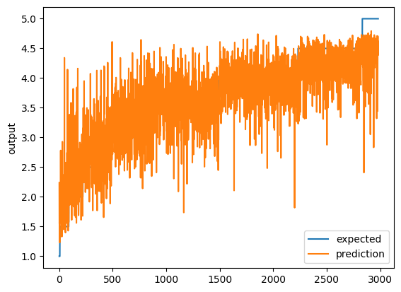

```python
# Define ModelCheckpoint outside the loop
checkpointer = ModelCheckpoint(filepath="dnn/best_weights.hdf5", verbose=0, save_best_only=True) # save best model

for i in range(5):
    print(i)

    # Build network
    model = Sequential()
    model.add(Dense(100, input_dim=x.shape[1], activation='relu'))
    model.add(Dense(50, activation='relu'))
    model.add(Dense(25, activation='relu'))
    model.add(Dense(1))
    model.compile(loss='mean_squared_error', optimizer='adam')
    monitor = EarlyStopping(monitor='val_loss', min_delta=1e-3, patience=5, verbose=1, mode='auto')

    model.fit(x_train,y_train,validation_data=(x_test,y_test),callbacks=[monitor,checkpointer],verbose=2,epochs=1000)


model.load_weights('dnn/best_weights.hdf5') # load weights from best model


# Predict and measure RMSE
pred = model.predict(x_test)

score = np.sqrt(metrics.mean_squared_error(pred,y_test))
print("Score (RMSE): {}".format(score))

# Plot the chart
chart_regression(pred.flatten(),y_test, sort= True)
```

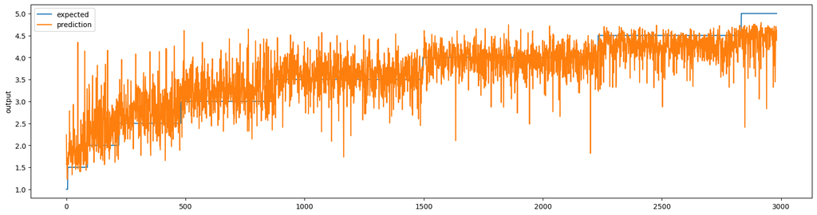

```python
# Regression chart.
def chart_regression(pred,y,sort=True):
    t = pd.DataFrame({'pred' : pred, 'y' : y.flatten()})
    if sort:
        t.sort_values(by=['y'],inplace=True)
    plt.figure(figsize=(20, 5))
    a = plt.plot(t['y'].tolist(),label='expected')
    b = plt.plot(t['pred'].tolist(),label='prediction')
    plt.ylabel('output')
    plt.legend()
    plt.show()

# Plot the chart
chart_regression(pred.flatten(),y_test, sort= True)
```

```python
# print out prediction
df_y = pd.DataFrame(y_test, columns=['ground_truth'])
df_pred = pd.DataFrame(pred, columns=['predicted'])
result = pd.concat([df_y, df_pred],axis=1)

result[:5]
```

|  | ground_truth | predicted |
| --- | --- | --- |
| 0 | 5.0 | 4.615991 |
| 1 | 3.0 | 3.648290 |
| 2 | 4.0 | 4.184994 |
| 3 | 3.0 | 3.598692 |
| 4 | 4.5 | 3.969010 |